# Data Analysis and Lab_Lab 3

Na SeungChan

2023-09-24

# Exercise 1

## (a) Create a scatter plot of each person’s height against their father’s height

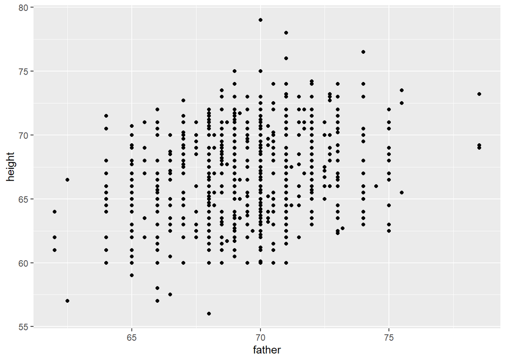

```r
ggplot(data = Galton) +
  geom_point(mapping = aes(x = father, y = height))
```

## (b) Separate your plot into facets by sex

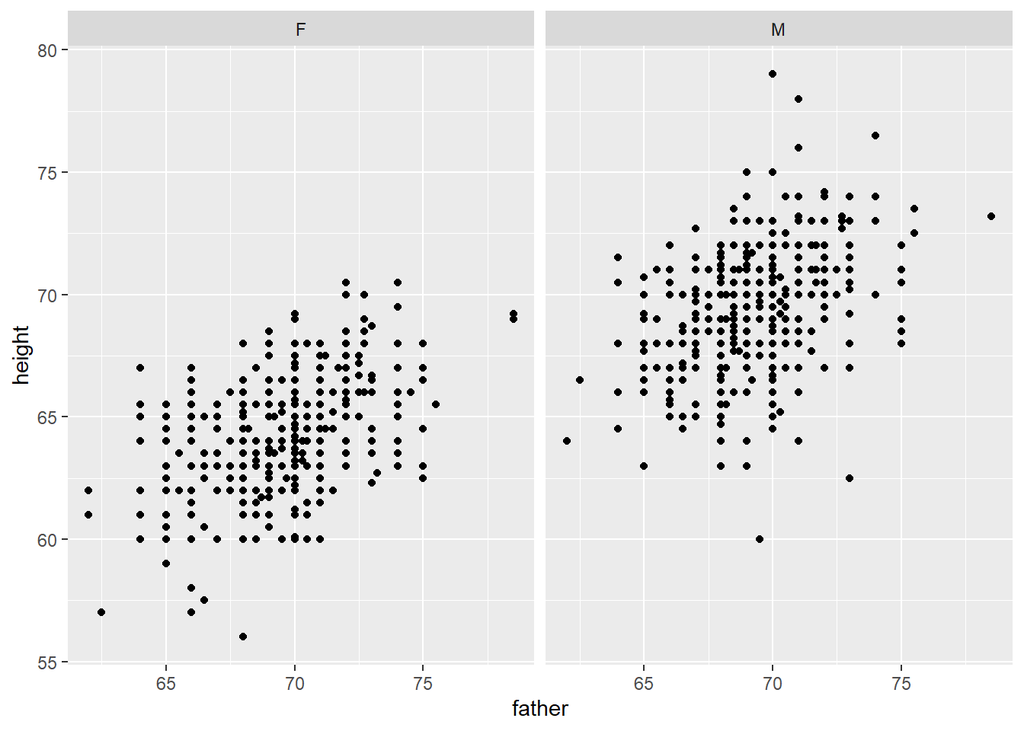

```r
ggplot(data = Galton) +
  geom_point(mapping = aes(x = father, y = height)) +
  facet_wrap(~sex)
```

## (c) Add regression lines to all of your facets; use `geom_smooth(method = "lm")`.

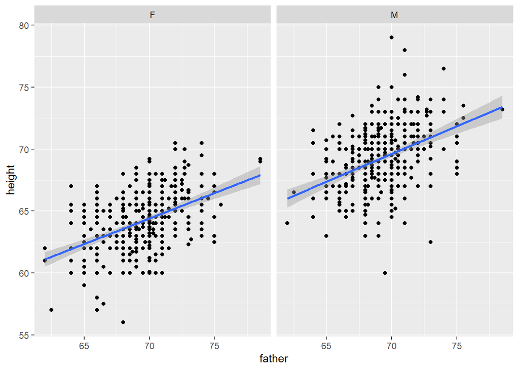

```r
ggplot(data = Galton) +
  geom_point(mapping = aes(x = father, y = height)) +
  facet_wrap(~sex) +
  geom_smooth(mapping = aes(x = father, y = height), method = "lm", formula = y ~ x)
```

## (d) Analyze the results of (a), (b) and (c) in 2 ~ 3 sentences.

산점도상 자녀의 키와 아버지의 키는 그래프로 봤을 때 양의 상관관계를 가지는 것으로 보인다. 이와 같은 결과는 ’남성과 여성의 키 차이를 고려’하여 자녀의 성별에 따라 서로 다른 facet에 각 그래프를 그려도 동일하게 나타난다. 실제 이에 따라 회귀직선을 mapping해 본 경우에도 비슷한 결과가 나온다.

# Exercise 2

```r
MLB_teams
```

## (a) See how many variables you can illustrate on a single plot in R. The current record is 7. [Note: this is not good graphical practice—it is merely an exercise to help you understand how to use visual cues and aesthetics!]

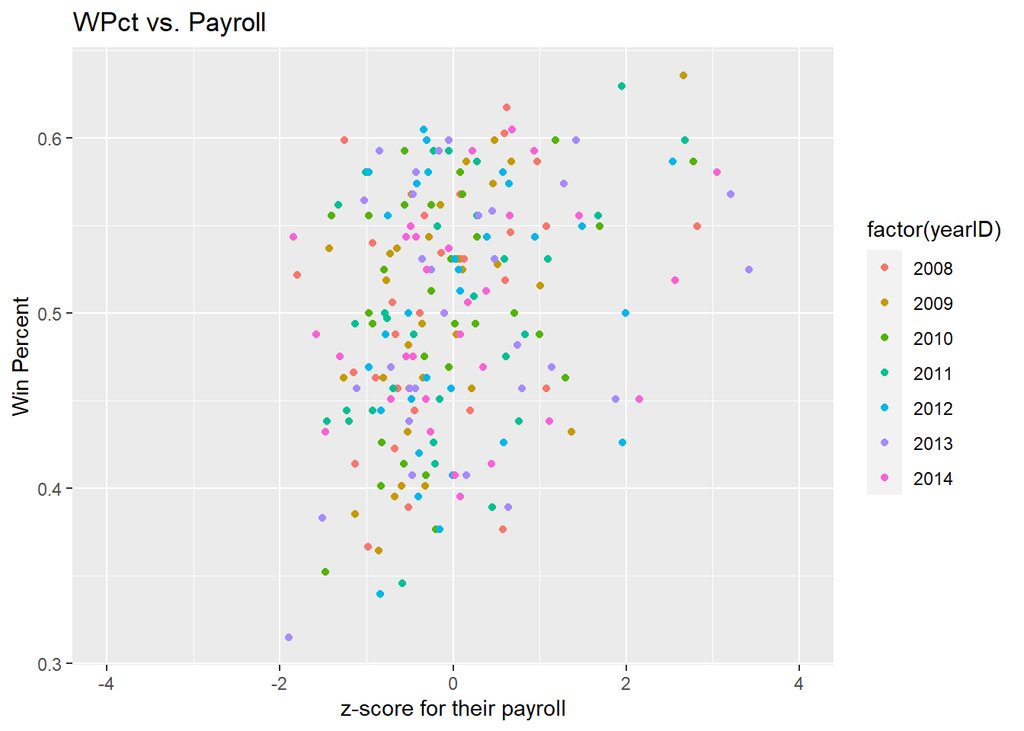

```r
MLB_teams %>%
  mutate(z_pay = (payroll-mean(payroll))/sd(payroll)) %>%
  ggplot() +
  geom_point(mapping = aes(x = z_pay, y = WPct, color = factor(yearID))) +
  xlim(-4,4) +
  xlab('z-score for their payroll') +
  ylab('Win Percent') +
  labs(title = 'WPct vs. Payroll')
```

## (b) Use the `MLB_teams` data in the `mdsr` package to create an informative data graphic that illustrates the relationship between winning percentage `WPct` and payroll `payroll` in context.

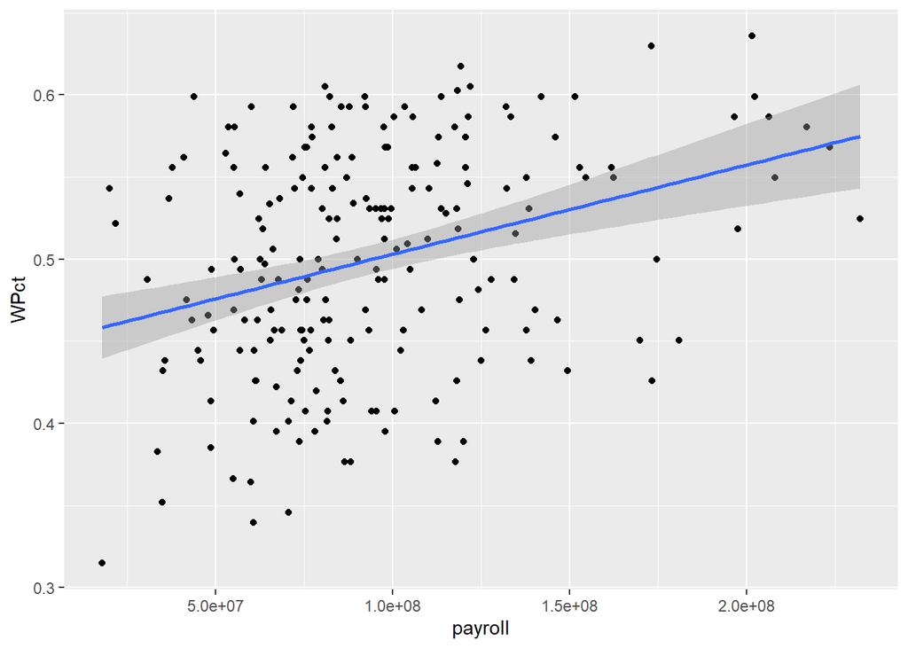

```r
ggplot(data = MLB_teams, mapping = aes(x = payroll, y = WPct)) +
  geom_point() +
  geom_smooth(method = "lm")
```

Overall there is a positive correlation between payroll and WPct. However, overall payroll tends to increase as time goes.

```r
MLB_teams %>%
  group_by(yearID) %>%
  summarise(sum(payroll))
```

| yearID | sum(payroll) |
| --- | --- |
| 2008 | 2684858670 |
| 2009 | 2664726994 |
| 2010 | 2721359865 |
| 2011 | 2784505291 |
| 2012 | 2932741192 |
| 2013 | 3034525648 |
| 2014 | 2994000466 |

So, we will use z-score. In z-scores, we can see teams below -2.0 did not exist, but teams with z-scores over 3.0 was 3 teams.

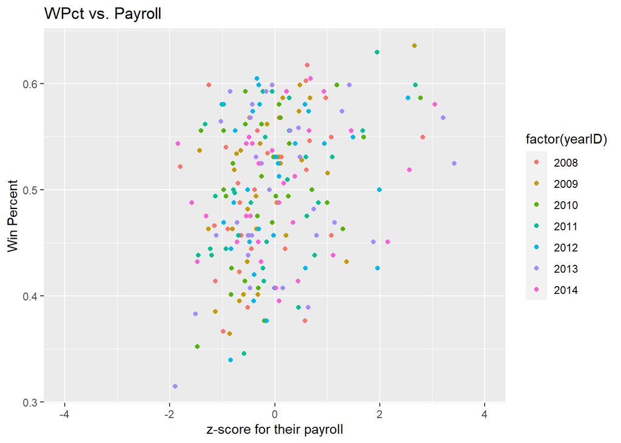

```r
MLB_teams %>%
  mutate(z_pay = (payroll-mean(payroll))/sd(payroll)) %>%
  ggplot() +
  geom_point(mapping = aes(x = z_pay, y = WPct, color = factor(yearID))) +
  xlim(-4,4) +
  xlab('z-score for their payroll') +
  ylab('Win Percent') +
  labs(title = 'WPct vs. Payroll')
```

# Exercises 3 : Write a code to create a data object named `Binary_medv` whose value is `"rich"` if the value of `medv` is greater than 25, `"not so"` if not. Use both `with()` and `ifelse()`.

```r
my_Boston <- Boston %>%
  mutate(Binary_medv = with(Boston, ifelse(medv > 25, 'rich', 'not so'))) %>%
  relocate(Binary_medv)
head(my_Boston)
```

|  | Binary_medv | crim | zn | indus | chas | nox | rm | age | dis | rad | tax | ptratio | black | lstat | medv |
| --- | --- | --- | --- | --- | --- | --- | --- | --- | --- | --- | --- | --- | --- | --- | --- |
| 1 | not so | 0.00632 | 18 | 2.31 | 0 | 0.538 | 6.575 | 65.2 | 4.0900 | 1 | 296 | 15.3 | 396.90 | 4.98 | 24.0 |
| 2 | not so | 0.02731 | 0 | 7.07 | 0 | 0.469 | 6.421 | 78.9 | 4.9671 | 2 | 242 | 17.8 | 396.90 | 9.14 | 21.6 |
| 3 | rich | 0.02729 | 0 | 7.07 | 0 | 0.469 | 7.185 | 61.1 | 4.9671 | 2 | 242 | 17.8 | 392.83 | 4.03 | 34.7 |
| 4 | rich | 0.03237 | 0 | 2.18 | 0 | 0.458 | 6.998 | 45.8 | 6.0622 | 3 | 222 | 18.7 | 394.63 | 2.94 | 33.4 |
| 5 | rich | 0.06905 | 0 | 2.18 | 0 | 0.458 | 7.147 | 54.2 | 6.0622 | 3 | 222 | 18.7 | 396.90 | 5.33 | 36.2 |
| 6 | rich | 0.02985 | 0 | 2.18 | 0 | 0.458 | 6.430 | 58.7 | 6.0622 | 3 | 222 | 18.7 | 394.12 | 5.21 | 28.7 |